# persp

## persp

theta phi r d ltheta lphi col border

This behaves a bit like image in that it needs at least three arguments:

- **x** - a vector of unique x-values
- **y** - a vector of unique y-values
- **z** - a matrix of z-values

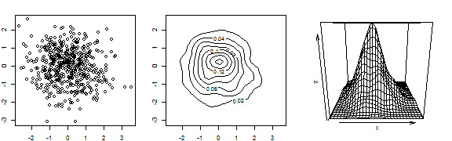

```r
set.seed(3)
x = rnorm(500)
y = rnorm(500)
par(mfrow = c(1, 3), mar = c(2, 2, 2, 2), oma = c(0, 0, 0, 0))
plot(x, y, asp = 1)
suppressMessages(require(MASS))
n = 30
f = kde2d(x, y, n = n)  # kernel density estimation
x = f$x
y = f$y
z = f$z
contour(x, y, z, asp = 1)
persp(x, y, z)
```

### theta

This rotates the figure theta degrees clockwise about the **vertical** axis.

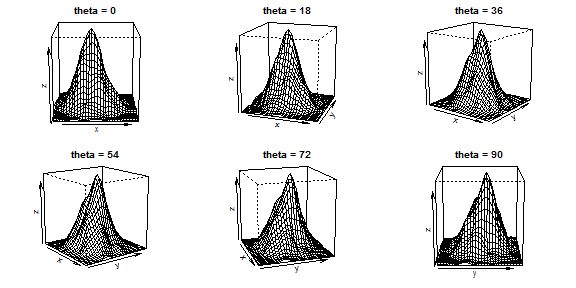

```r
par(mfrow = c(2, 3), mar = c(2, 2, 2, 2), oma = c(0, 0, 0, 0))
for (i in seq(0, 90, length = 6)) persp(x, y, z, theta = i, main = paste("theta =",
    i), phi = 15, d = 5)
```

[back to top]

### phi

This rotates the figure phi degrees about the **horizontal** axis.

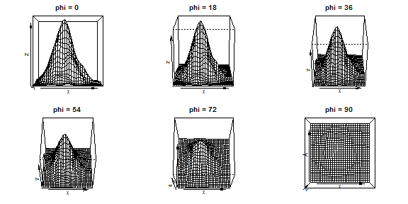

```r
par(mfrow = c(2, 3), mar = c(2, 2, 2, 2), oma = c(0, 0, 0, 0))
for (i in seq(0, 90, length = 6)) persp(x, y, z, phi = i, main = paste("phi =",
    i), d = 5)
```

[back to top]

### r

This controls the **perspective**.

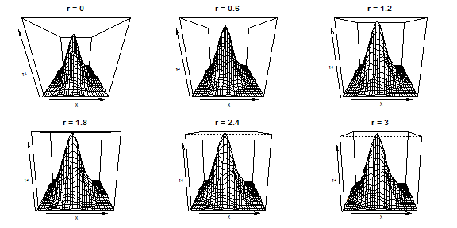

```r
par(mfrow = c(2, 3), mar = c(2, 2, 2, 2), oma = c(0, 0, 0, 0))
for (i in seq(0, 3, length = 6)) persp(x, y, z, r = i, main = paste("r =", i))
```

[back to top]

### d

This also controls the **perspective**.

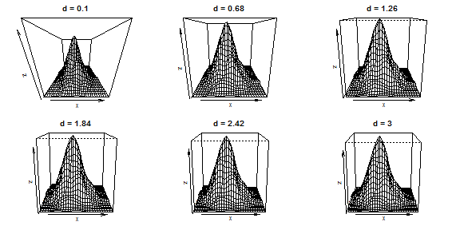

```r
par(mfrow = c(2, 3), mar = c(2, 2, 2, 2), oma = c(0, 0, 0, 0))
for (i in seq(0.1, 3, length = 6)) persp(x, y, z, d = i, main = paste("d =",
    i))
```

[back to top]

### shade

This controls the degree of **contrast** between lit areas and unlit areas.

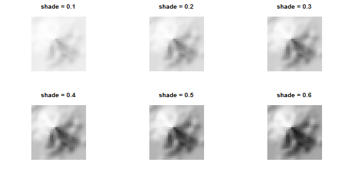

```r
par(mfrow = c(2, 3), mar = c(2, 2, 2, 2), oma = c(0, 0, 0, 0))
for (i in seq(0.1, 0.6, length = 6)) persp(x, y, z, shade = i, main = paste("shade =",
    i), theta = 0, phi = 90, border = NA, box = FALSE, d = 10)
```

[back to top]

### ltheta

This controls the angle of **lighting** about the **vertical** axis (relative to the surface).

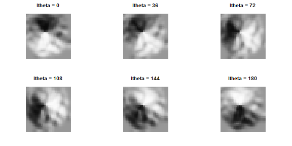

```r
par(mfrow = c(2, 3), mar = c(2, 2, 2, 2), oma = c(0, 0, 0, 0))
for (i in seq(0, 180, length = 6)) persp(x, y, z, shade = 0.75, ltheta = i,
    main = paste("ltheta =", i), theta = 0, phi = 90, border = NA, box = FALSE,
    d = 10)
```

[back to top]

### lphi

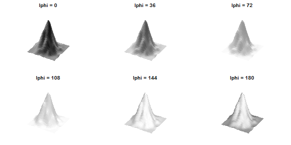

```r
par(mfrow = c(2, 3), mar = c(2, 2, 2, 2), oma = c(0, 0, 0, 0))
for (i in seq(0, 180, length = 6)) persp(x, y, z, shade = 0.75, lphi = i, main = paste("lphi =",
    i), theta = 30, phi = 30, border = NA, box = FALSE, d = 10)
```

[back to top]

### col

You can use simple colors.

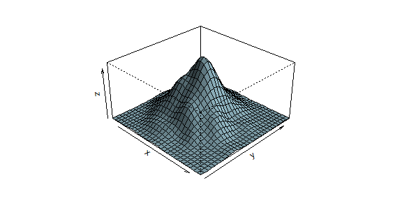

```r
par(mar = c(2, 2, 2, 2), oma = c(0, 0, 0, 0))
persp(x, y, z, col = "lightblue", theta = 45, phi = 30, shade = 0.5, ltheta = 160,
    d = 3, expand = 0.5)
```

Complicated colours are more difficult. You can give a vector of colours that is the same length as the number of grid squares but it's quite tricky, since the number of grid squares is (nx-1)(ny-1).

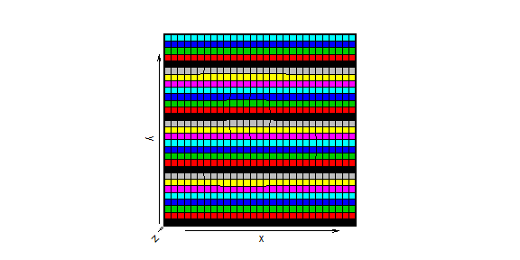

```r
par(mar = c(2, 2, 2, 2), oma = c(0, 0, 0, 0))
persp(x, y, z, col = rep(1:(n - 1), each = n - 1), phi = 90, d = 100)
```

So to get colours for each of the grid squares you need to find the height of the centre of each grid square.

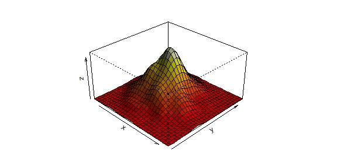

```r
# function to make a vector of colours
persp.cols = function(z, ncols = 10) {
    grid.means <- (z[-1, -1] + z[-1, -ncol(z)] + z[-nrow(z), -1] + z[-nrow(z),
        -ncol(z)])/4
    heat.colors(ncols)[cut(grid.means, ncols)]
}

par(mar = c(2, 2, 2, 2), oma = c(0, 0, 0, 0))
persp(x, y, z, col = persp.cols(z, 10), theta = 45, phi = 30, shade = 0.5, ltheta = 160,
    d = 3, expand = 0.5)
```

[back to top]

### border

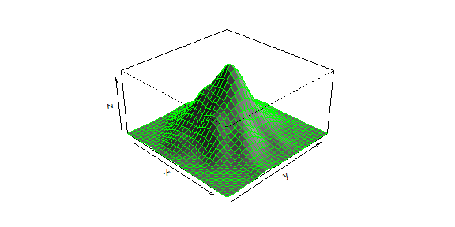

```r
par(mar = c(2, 2, 2, 2), oma = c(0, 0, 0, 0))
persp(x, y, z, col = "grey", theta = 45, phi = 30, shade = 1, ltheta = 160,
    d = 3, expand = 0.5, border = "green")
```

[back to R functions]

[back to Index]